# The_Analysis_Covid19_Brazil

A.A.M.M.Adikari

7/15/2020

## Introduction

The coronavirus COVID-19 pandemic is the most dangerous and significant challenge the whole world had to face in 2019-2020. This coronavirus has spread over every continent and has a massive effect on world health. In the health sector and the economy, political and social divisions turned upside down. This coronavirus is an unexpected situation for the whole world, and nobody was ready for that. Therefore, powerful world countries also flatted because of this pandemic. When considering Brazil, it is the largest country in both South America and Latin America. At 8.5 million square kilometers (3.2 million square miles) and with over 211 million people, Brazil is the world’s fifth-largest country by area and the sixth-most populous. The Atlantic Ocean bounds Brazil on the east, and it borders all other countries in South America except Ecuador and Chile. Therefore, investigating the Brazil corona situation is very interesting and very important.

**Figure 01: Brazil in world map**

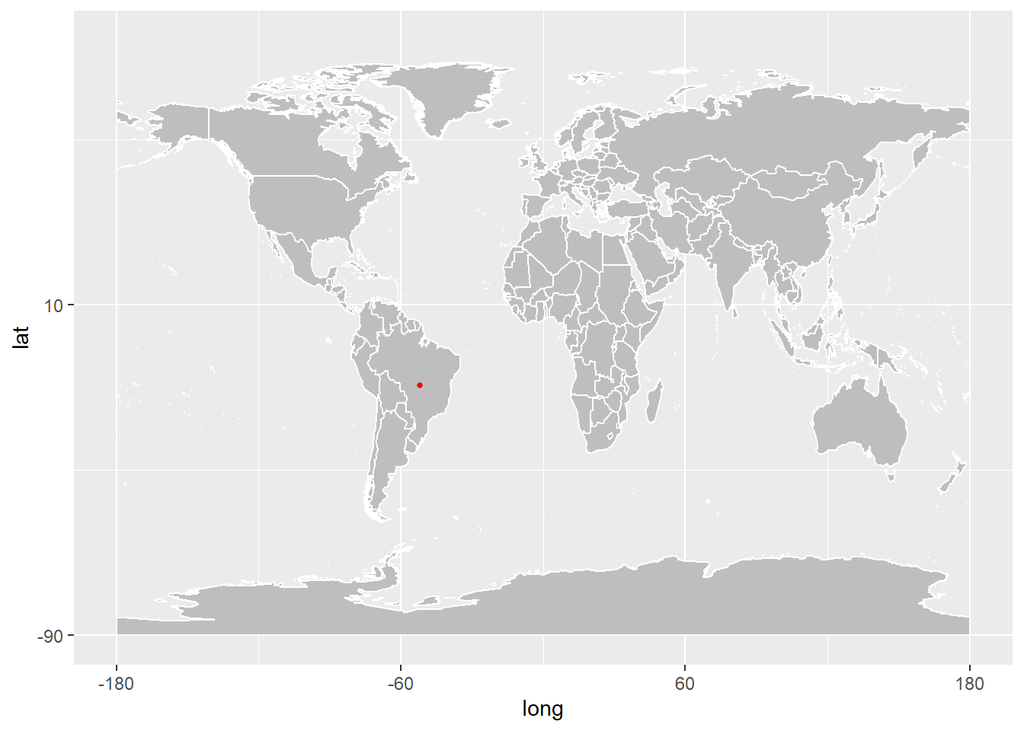

The scientist found out the coronavirus is destroying at 40 °Cs. Moreover, there was a rumor about the spreading cast of coronaviruses low in high-temperature countries. Therefore, when investigating the corona situation in Brazil, we must consider the climate situation. The central parts of the Brazilian Highlands receive most of their precipitation during the summer months (November to April) Storms and floods may strike the Northeast at that time. Summer temperatures are mostly uniform. In January, most of the lowlands average roughly 79 °F (26 °C), and the mountains are a few degrees cooler, depending on elevation. The hottest region of the country, averages some 84 °F (29 °C), with daytime temperatures exceeding 100 °F (38 °C). In the winter (May to October), the Brazilian Highlands are generally dry and snow pitfalls in only a few southernmost states. Winter temperatures in the Amazon lowlands remain virtually unchanged from those of the summer months, but temperatures in the drought quadrilateral drop to about 79 °F (26 °C). Temperatures in the Brazilian Highlands average about 68 °F (20 °C) in the central and northern regions and are more lukewarm toward the south averages 57 °F (14 °C) in June and July. By considering these situations, Brazil usually has less than 40 °C temperatures.

Brazil’s coronavirus outbreak is one of the world’s most severe, with more than 2m cases recorded since March. On 25th February, Brazil recorded its first Covid-19 case, and the first death was recorded on 17th March 2020. On 20th March, the government of Rio Grande do Norte declared a public emergency, and the day after, cases in São Paulo rose almost 40% in two hours. Deaths also increased in the period. The state issued a lockdown order for non-essential businesses, lasting from 24th March through at least 7th April. Cities in the Campinas region declared an emergency. 9th April 2020, the federal government sent out its first financial assistance to the public. Over 2.5 million people received R$600 ($116). After days, on 20th April, Several cities started to ease social isolation guidelines in favor of contact tracing. Some retail stores were allowed to open as long as customers wore masks, the number of in-person customers has reduced, and customer personal information tracked. 7th May, several cities in the northern states of Amazonas and Pará began issuing lockdown measures to curb the spread of the virus. Other cities in other countries consider doing the same. Two days, the government of Rio Grande does Sul established a new social distancing plan.

However, it was not long before the virus spread to major cities like Rio de Janeiro and São Paulo. Cases then began to rise sharply. In May, São Paulo’s mayor warned that its underfunded health system was on the verge of collapse as it became a new hotspot for Covid-19. He said demand for hospital beds had skyrocketed. This hospital, built inside a sports gym in the city, is one of many makeshift facilities that opened up. However, despite the rise in cases, there was still no national lockdown. States and cities adopted their measures, but protests met these, and data later showed that compliance lessened as time went on. Stay-at-home orders and other restrictions are critics by far-right President Jair Bolsonaro, who denounced them as “dictatorial.” He even joined anti-lockdown protests in the capital, Brasilia. Mr. Bolsonaro has repeatedly played down the risks of what he calls “little flu,” and his response to the pandemic has been slowly critics. He has argued that regional lockdowns have a more damaging effect than the virus itself, and accused the media of spreading panic and paranoia. The president has also been spot meeting supporters while not wearing a mask, such as in Brasilia. 5th June Brazilian government shuts down the official website with COVID-19 daily reports and will no longer report the total number of deaths and active cases. 9th June A court order forces the Brazilian government to continue publishing cumulative cases and death counts.

On 20th June, Brazil became only the second country to pass one million cases, and that number has continued to rise steadily. Experts say it is likely much higher due to a lack of testing. However, lockdowns lifted even as cases surged. In Rio and São Paulo, restaurants and bars reopened despite the continued increase in transmissions. Today (2020.07.20), it is the second-worst affected country behind the U.S. More than 74,000 people have died with the virus due to a lack of testing. Furthermore, the exact figures believed to be even higher. As critics and the media says, cause to the current situation in Brazil was an idiotic, careless policy of the government and its presidents.

## Data Exploration

### Qualitative data

- **date** - The date of the summary
- **province** - The province or state, when applicable
- **country** - The country or region name
- **type** - the type of case (i.e., confirmed, death)

### Quantitative data

- **lat** - Latitude point
- **long** - Longitude point
- **cases** - the number of daily cases (corresponding to the case type)

**Table 01: Top 10 countries in corona confirmed cases**

```
# A tibble: 10 x 2
   country        total_confirmed_cases
   <chr>                          <int>
 1 US                           4562038
 2 Brazil                       2662485
 3 India                        1695988
 4 Russia                        838461
 5 South Africa                  493183
 6 Mexico                        424637
 7 Peru                          407492
 8 Chile                         355667
 9 United Kingdom                304793
10 Iran                          304204
```

**Table 02: Top 10 countries in corona death cases**

```
# A tibble: 10 x 2
   country        total_death_cases
   <chr>                      <int>
 1 US                        153314
 2 Brazil                     92475
 3 Mexico                     46688
 4 United Kingdom             46204
 5 India                      36511
 6 Italy                      35141
 7 France                     30268
 8 Spain                      28445
 9 Peru                       19021
10 Iran                       16766
```

**Table03: Summary of Brazil Corona data set**

```r
library(coronavirus)
data(coronavirus)
library(tidyverse)
library(magrittr)
brazil<-brazil_corona%>% mutate(cases = replace(cases, which(cases < 0), NA))
summary(brazil)
```

```
      date              province           country               lat
 Min.   :2020-01-22   Length:576         Length:576         Min.   :-14.23
 1st Qu.:2020-03-09   Class :character   Class :character   1st Qu.:-14.23
 Median :2020-04-26   Mode  :character   Mode  :character   Median :-14.23
 Mean   :2020-04-26                                         Mean   :-14.23
 3rd Qu.:2020-06-13                                         3rd Qu.:-14.23
 Max.   :2020-07-31                                         Max.   :-14.23
      long            type               cases
 Min.   :-51.93   Length:576         Min.   :     0
 1st Qu.:-51.93   Class :character   1st Qu.:     0
 Median :-51.93   Mode  :character   Median :   747
 Mean   :-51.93                      Mean   :  8271
 3rd Qu.:-51.93                      3rd Qu.:  9325
 Max.   :-51.93                      Max.   :140050
```

**Figure02: Time Series plot of Brazil Corona according to type**

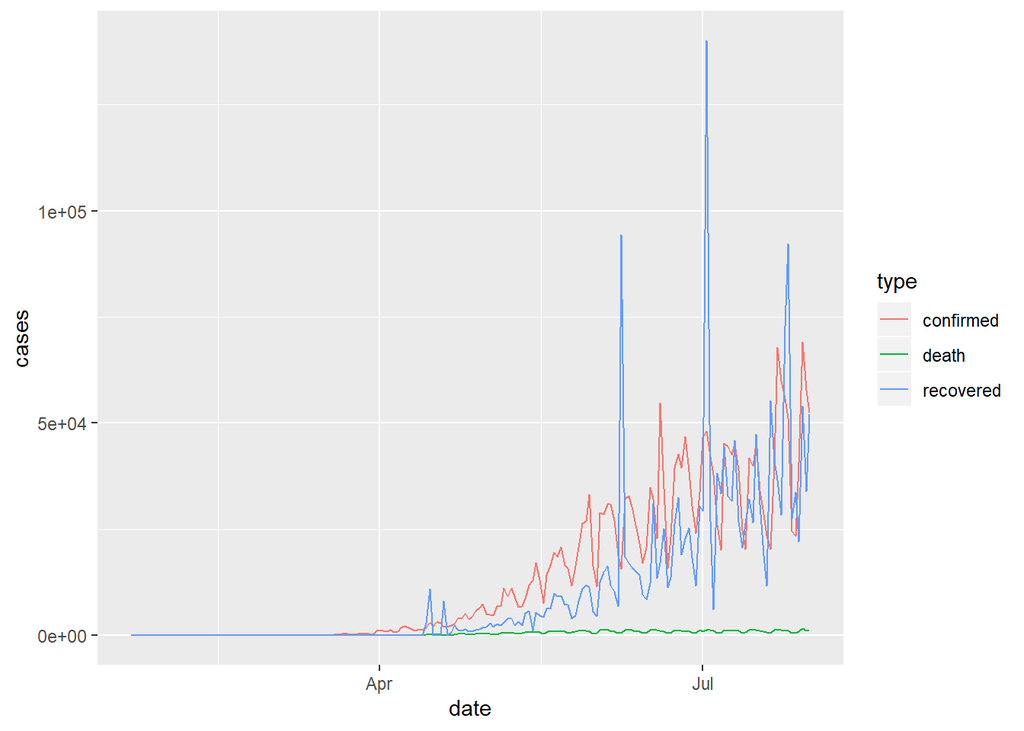

**Figure03: Histogram of Brazil Corona confirmed cases**

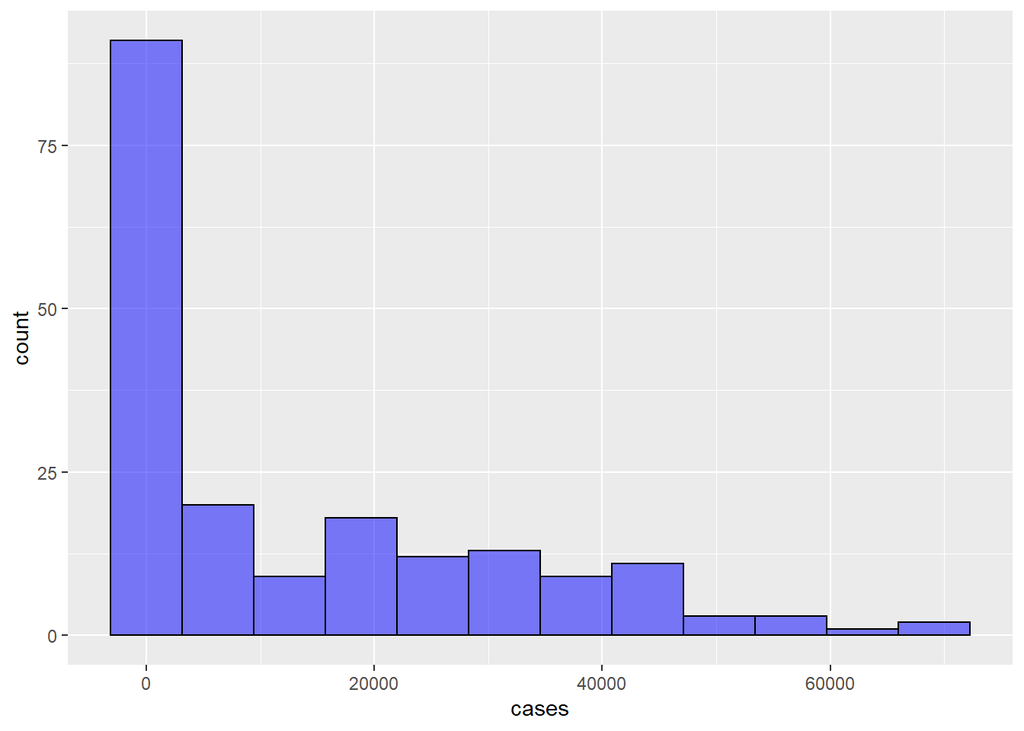

**Table04: Summary of Brazil Corona confirmed data set**

```
      date              province           country               lat
 Min.   :2020-01-22   Length:192         Length:192         Min.   :-14.23
 1st Qu.:2020-03-09   Class :character   Class :character   1st Qu.:-14.23
 Median :2020-04-26   Mode  :character   Mode  :character   Median :-14.23
 Mean   :2020-04-26                                         Mean   :-14.23
 3rd Qu.:2020-06-13                                         3rd Qu.:-14.23
 Max.   :2020-07-31                                         Max.   :-14.23
      long            type               cases
 Min.   :-51.93   Length:192         Min.   :    0.00
 1st Qu.:-51.93   Class :character   1st Qu.:    6.75
 Median :-51.93   Mode  :character   Median : 4536.00
 Mean   :-51.93                      Mean   :13867.11
 3rd Qu.:-51.93                      3rd Qu.:24641.25
 Max.   :-51.93                      Max.   :69074.00
```

**Figure04: Histogram of Brazil Corona death cases**

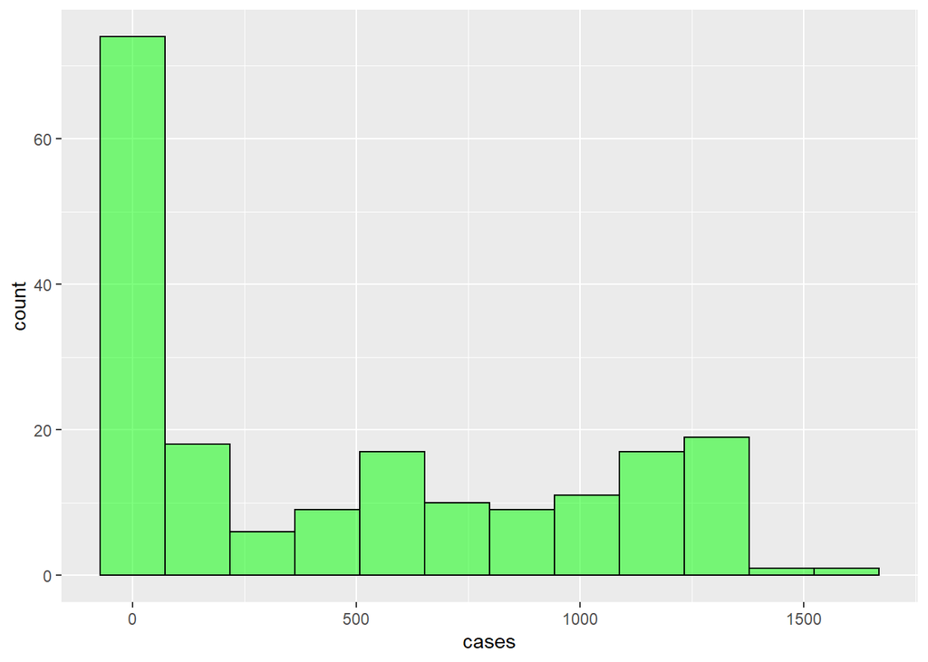

**Table05: Summary of Brazil Corona death data set**

```
      date              province           country               lat
 Min.   :2020-01-22   Length:192         Length:192         Min.   :-14.23
 1st Qu.:2020-03-09   Class :character   Class :character   1st Qu.:-14.23
 Median :2020-04-26   Mode  :character   Mode  :character   Median :-14.23
 Mean   :2020-04-26                                         Mean   :-14.23
 3rd Qu.:2020-06-13                                         3rd Qu.:-14.23
 Max.   :2020-07-31                                         Max.   :-14.23
      long            type               cases
 Min.   :-51.93   Length:192         Min.   :   0.0
 1st Qu.:-51.93   Class :character   1st Qu.:   0.0
 Median :-51.93   Mode  :character   Median : 333.0
 Mean   :-51.93                      Mean   : 481.6
 3rd Qu.:-51.93                      3rd Qu.: 957.8
 Max.   :-51.93                      Max.   :1595.0
```

**Figure05: Histogram of Brazil Corona recovered cases**

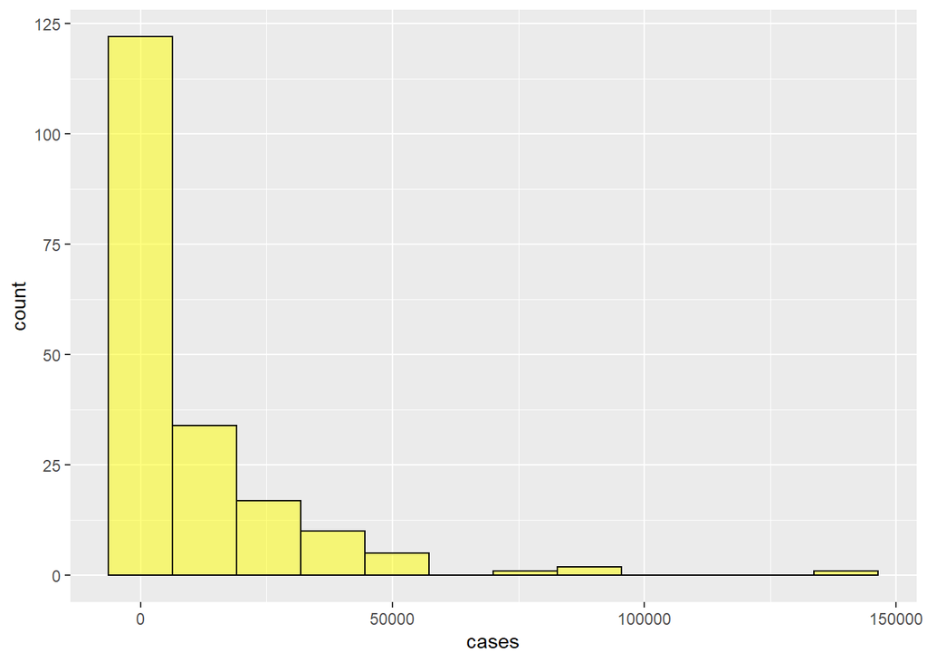

**Table06: Summary of Brazil Corona recovered data set**

```
      date              province           country               lat
 Min.   :2020-01-22   Length:192         Length:192         Min.   :-14.23
 1st Qu.:2020-03-09   Class :character   Class :character   1st Qu.:-14.23
 Median :2020-04-26   Mode  :character   Mode  :character   Median :-14.23
 Mean   :2020-04-26                                         Mean   :-14.23
 3rd Qu.:2020-06-13                                         3rd Qu.:-14.23
 Max.   :2020-07-31                                         Max.   :-14.23
      long            type               cases
 Min.   :-51.93   Length:192         Min.   :     0
 1st Qu.:-51.93   Class :character   1st Qu.:     0
 Median :-51.93   Mode  :character   Median :  1696
 Mean   :-51.93                      Mean   : 10463
 3rd Qu.:-51.93                      3rd Qu.: 13555
 Max.   :-51.93                      Max.   :140050
```

**Brazil compare with USA**

**Figure06: Density plot of Brazil and USA Corona confirmed cases**

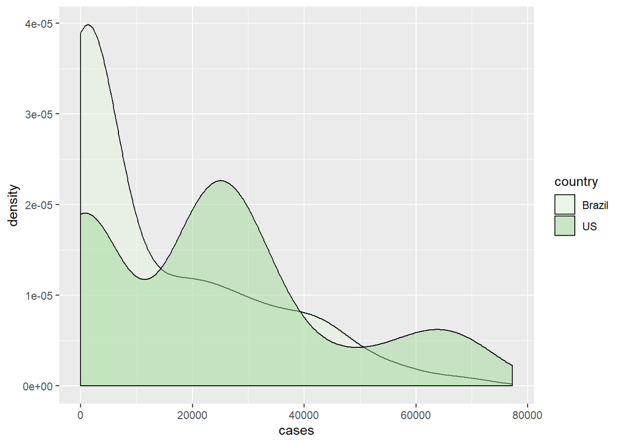

**Figure07: Density plot of Brazil and USA Corona death cases**

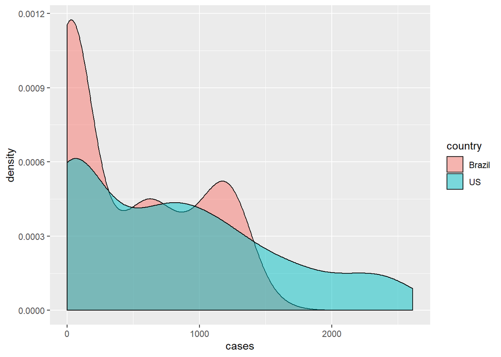

**Brazil compare with Peru & Argentina**

**Figure08: Density plot of Brazil and Peru and Argentina Corona confirmed cases**

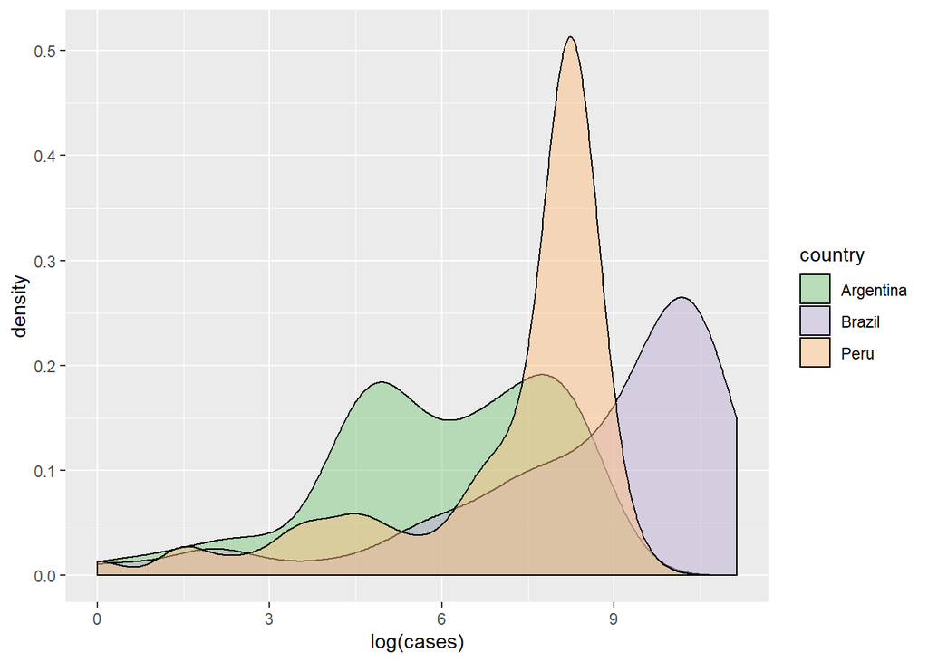

**Figure09: Density plot of Brazil and Peru and Argentina Corona death cases**

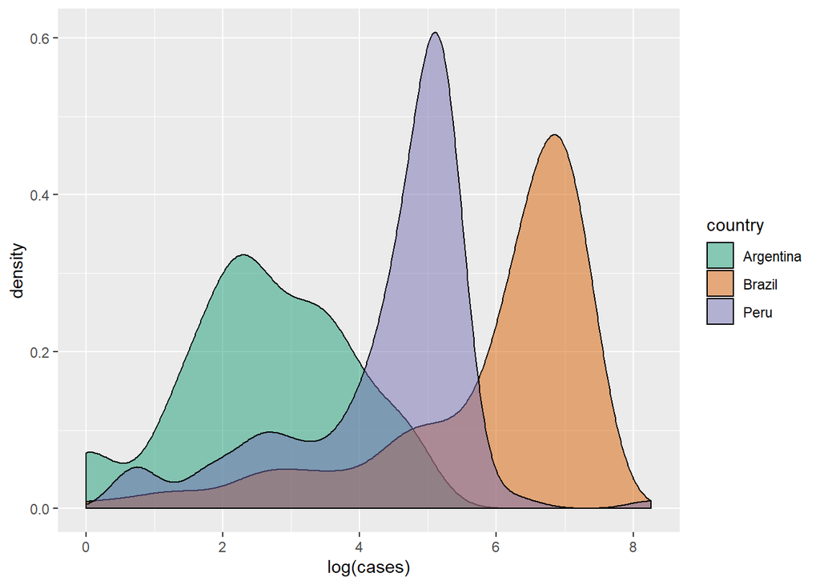

**Figure10: Density plot of Brazil and Peru and Argentina Corona recovered cases**

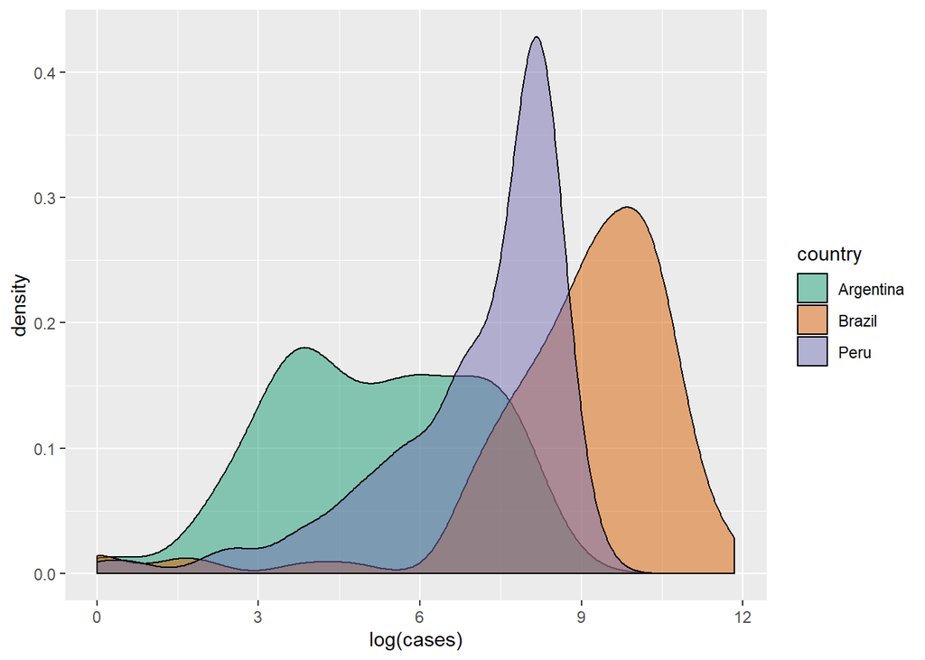

here,I consider the log values because normal values are not displayed well. According to Figure08, Figure09, Figure10 Brazil ha the high confirmed cases,death cases and recovered cases compared to Peru and Argentina.

**Timeseries model for Brazil confiremed cases**

```
Series: confirmed_brazil_corona$cases
ARIMA(2,1,2) with drift

Coefficients:
         ar1      ar2      ma1     ma2     drift
      1.1055  -0.7466  -1.5228  0.6947  251.5656
s.e.  0.0621   0.0573   0.0673  0.0665  103.0520

sigma^2 estimated as 28368704:  log likelihood=-1908.53
AIC=3829.06   AICc=3829.51   BIC=3848.57
```

**Figure11:Time series forecast of Brazil confirmed cases**

[figure not shown]

```
    Point Forecast    Lo 80    Hi 80    Lo 95    Hi 95
193       45045.08 38219.24 51870.92 34605.86 55484.29
194       41487.95 33587.61 49388.29 29405.42 53570.48
195       43194.87 35280.22 51109.52 31090.46 55299.28
196       47898.76 39882.87 55914.65 35639.52 60158.00
197       51985.98 43948.76 60023.20 39694.11 64277.85
198       53154.06 44982.61 61325.51 40656.91 65651.22
199       51555.34 42764.46 60346.21 38110.86 64999.82
200       49077.13 39556.25 58598.01 34516.21 63638.05
201       47692.20 37769.28 57615.13 32516.39 62868.02
202       48172.51 38131.50 58213.52 32816.11 63528.91
203       49898.68 39827.12 59970.24 34495.56 65301.81
204       51609.70 41498.51 61720.88 36145.97 67073.42
205       52373.85 42140.37 62607.32 36723.10 68024.59
206       52102.53 41624.63 62580.43 36077.97 68127.09
```

[output cut: 36 more lines]

## References

- https://github.com/RamiKrispin/coronavirus
- https://www.britannica.com/place/Brazil/Climate
- https://en.wikipedia.org/wiki/COVID-19_pandemic_in_Brazil
- https://bookdown.org/yihui/rmarkdown-cookbook/figure-size.html